# Samson et Dalila

## Pressestimmen

> »Filmregisseur Damián Szifron entfacht an der Staatsoper mit ‚Samson et Dalila‘ ein Spektakel.«

> **Der Tagesspiegel, 26. November 2019**

> »Daniel Barenboim präsentiert die Partitur in klingendem Technicolor: Die leuchtenden, manchmal geradezu knallbunten Klangfarben der Staatskapelle klingen fantastisch – und nach weit mehr Musikerinnen und Musikern, als tatsächlich im Orchestergraben sitzen. Wie auch bei Verdi besteht Barenboims Taktik darin, maximale Präzision und Transparenz im Technischen mit leidenschaftlicher Dringlichkeit zu verbinden.«

> **Der Tagesspiegel, 26. November 2019**

> »Am allermeisten Spaß aber hat Michael Volle: Wie er lustvoll intrigiert, als Oberpriester Gift und Galle spuckt, während er sich selbstironisch beim Chargieren beobachtet – ein Jack Nicholson im Wallegewand, nur eben mit Luxusbariton. Das ist ganz große Cinemascope-Oper.«

> **Der Tagesspiegel, 26. November 2019**

> »Der Tenor Branden Jovanovich ist ein kraftvoller Samson, Michael Volle der alles beherrschende Oberpriester mit mächtiger Stimme und furchteinflößender Durchschlagskraft.«

> **Deutschlandfunk Kultur, 24. November 2019**

> »Szifron hat mit Elina Garanča als Dalila und Brandon Jovanovich als Samson zwei überragende Sänger, die sich auch darstellerisch auf ein Wagnis einlassen.«

> **Frankfurter Allgemeine Zeitung, 26. November 2019**

> »Alle, ob Michael Volle als Oberpriester, Kwangchul Youn als Abimélech oder Wolfgang Schöne als alter Hebräer, beweisen in dieser Aufführung, dass Eindringlichkeit mehr aus Genauigkeit denn aus Wucht entsteht.«

> **Frankfurter Allgemeine Zeitung, 26. November 2019**

> »Barenboim betrachtet im Orchester geradezu jedes Motiv, jedes Instrument als Person in einem klingenden Drama auch neben den Worten. […] Es ist herrlich! Man kann gar nicht genug davon bekommen.«

> **Frankfurter Allgemeine Zeitung, 26. November 2019**

> »Daniel Barenboim kostet mit der fabelhaft nuanciert spielenden Staatskapelle die stilistische Vielfalt der Partitur aus, von ihren sinnlich-flirrenden Klangfarben über die chromatisch gefärbten melodischen Linien bis zu den suggestiv aufgebauten Steigerungen des Bacchanals. Auch der präzise einstudierte Staatsopernchor hat keine Mühe, die Fugati der Trauer- und Jubelchöre klangschön mit Leben zu erfüllen.«

> **Süddeutsche Zeitung, 26. November 2019**

> »Michael Volle ist der Oberpriester, der Spielmacher par excellence. Sein Bariton verströmt die ganze dämonische Doppelbödigkeit eines Machtmenschen.«

> **Berliner Morgenpost, 26. November 2019**

> »Der Chor der Staatsoper ist in dieser Oper, die eher an die Oratorien-Tradition anknüpft, beeindruckend in der stilistischen Präzision. Die Staatskapelle unter Barenboim lässt den Sängern viel Spielraum und kostet darüber hinaus das Klangfarbenspiel bis in die orientalischen Akzente hinein aus.«

> **Berliner Morgenpost, 26. November 2019**

## Programmbuch

[Download](https://www.staatsoper-berlin.de/downloads-b/de/produktion/7651/programmbuch/bc9c8bf3efe05e426114c603ab2c0dc6/Samson_et_Dalila_Programmheft_Auflage_1_2019.pdf)

## Mehr erfahren

### Wie ein Filmdreh ohne Kamera

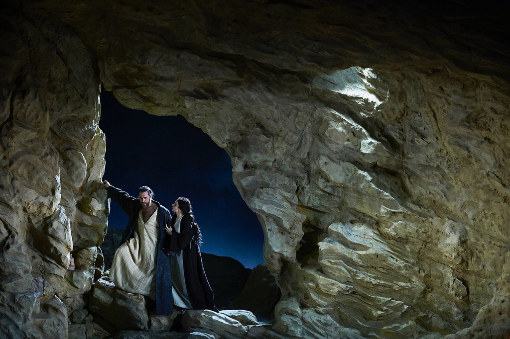

- Am 24. November feierte »Samson et Dalila« in der Inszenierung des argentinischen Filmregisseurs Damián Szifron Premiere. Während der Proben traf Dramaturgin Jana Beckmann ihn zum Gespräch.

### Femme Fatale oder Prostituierte, dazwischen nichts

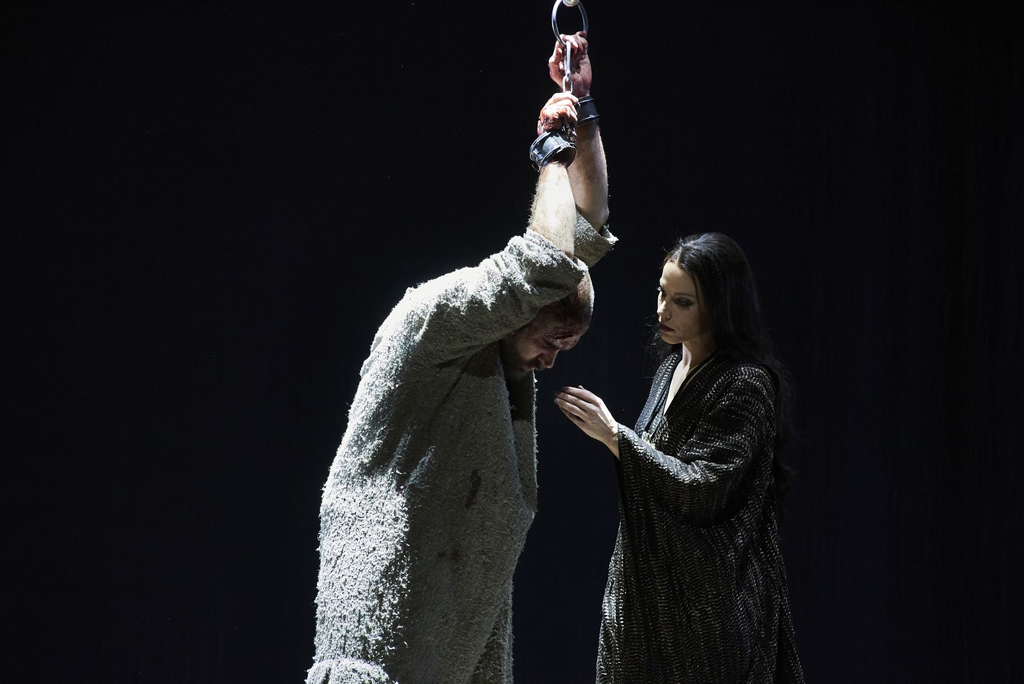

- Viele Facetten ihrer Person bleiben unausgesprochen oder weisen Widersprüche auf: Wer ist Dalila? Dramaturgin Jana Beckmann geht dieser Frage in einem Essay nach.
- Mit freundlicher Unterstützung der Britta Lohan Gedächtnisstiftung